# Weather file decomposition analysis

## Hilbert Huang decomposition basics

Here’s my quick review of what we’ve done so far.

We decomposed the dry bulb and dew point temperatures using the Hilbert Huang EMD[^1]. If you’re not familiar with the method, watch this talk by Norbert Huang:

[interactive chart not shown]

Assuming you understand all that, I’ll go on…

The EMD reduces a signal to a *residual* and a several *intrinsic mode functions* (IMFs). The sum of the EMFs and the residual is the original signal:

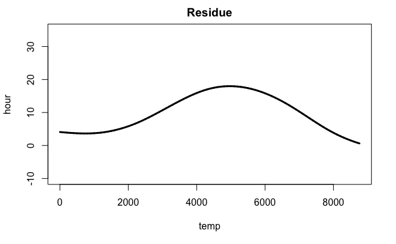

```r
 # emd analysis for one of the weather files
  weather.name = weather.file.select(file = 30, fold = 1)
  fileName="../../weather-files/DSY/Norwich_DSY3.epw"
  connection=file(fileName,open="r")
  header=readLines(connection)[1:8]
  weather.dat = read.table(fileName, skip = 8, header = FALSE, sep =',')
  close(connection)
  decomp=emd(weather.dat$V7, max.sift=6, boundary="wave", plot.imf=F)
  temp.lims = c(-10,35)
  plot(decomp$residue, main='Residue', type='l', lwd=3, ylim=temp.lims, ylab='hour', xlab='temp')
```

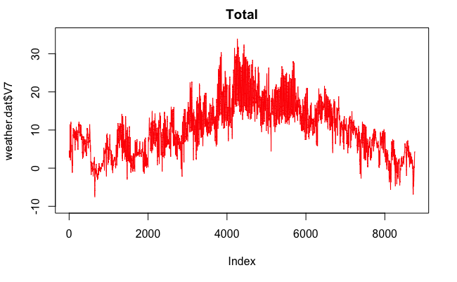

```r
  plot(weather.dat$V7, main='Total', type='l', col='red', lwd='red', ylim=temp.lims)
```

The IMFs can be thought of as the ‘noise’ on top of the residual’s ‘trend’. The IMFs are roughly symmetric about zero:

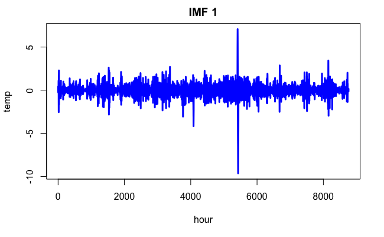

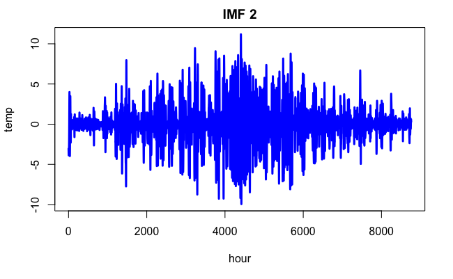

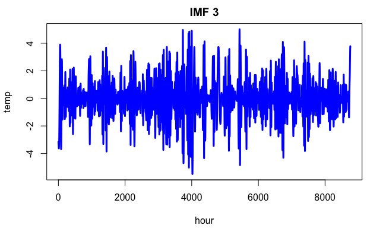

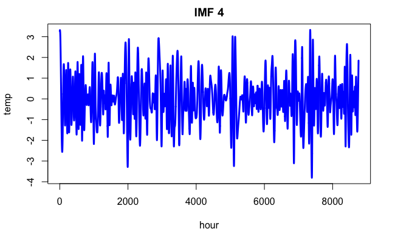

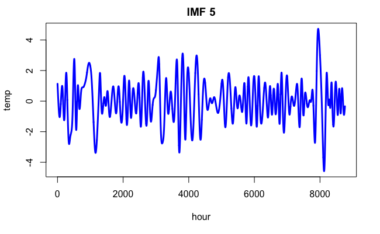

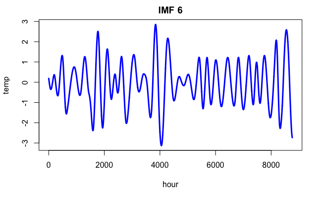

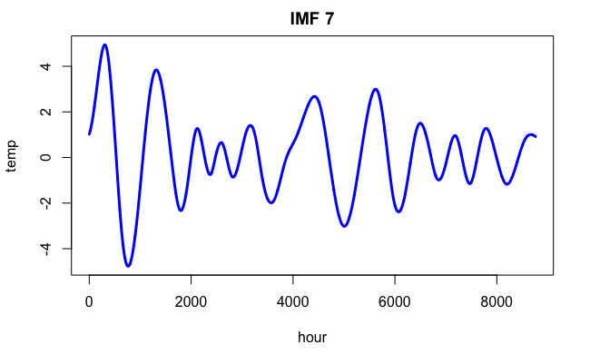

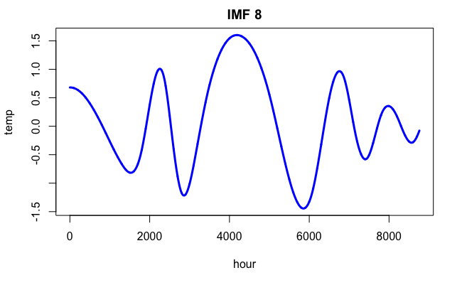

## How we use the IMFs and the residual

What we’ve done is relatively unsophisticated. We’ve took the trend:

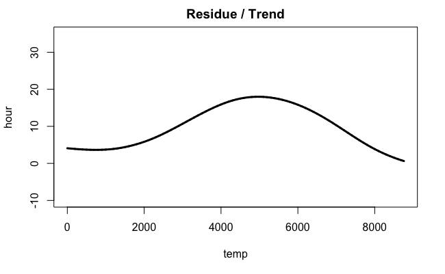

And the sum of **all** the IMFs (‘the rest’):

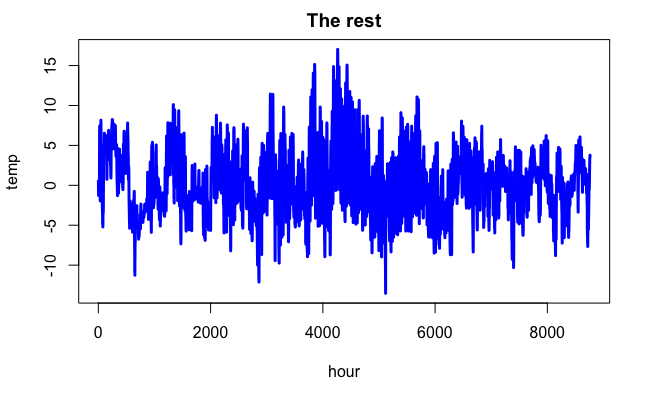

We can use the *residue* to *the rest* isolate different events:

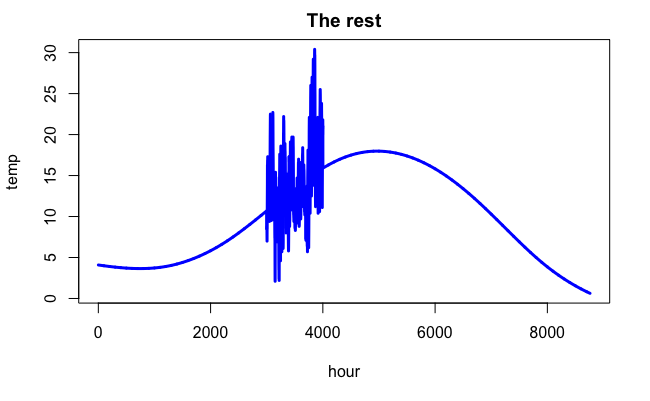

## CIBSE TM 52 overheating criteria

Our hypothesis is that most of the weather file is useless for overheating. The question is, which bits are useful and which bits are useless?

We’ve been using the CIBSE TM 52 overheating criteria to calculate overheating. Each of the CIBSE criteria arebased on $\Delta T$, which is the difference between the operational temperature $T_{op}$ and $T_{max}$:

$$\Delta T = T_{op} - T_{max}$$
And:

$$T_{max} = 0.33 T_{rm} + 21.8$$

Where $T_{rm}$ is the running mean.

The CIBSE criteria are:

- A. Number of hours where $\Delta T$ is greater than 1 should be less than 3% of occupied hours
- B. The maximum weighed exceedance should be less than 6 on *any* day.
- C. $\Delta T$ should never be greater than 4.

Both A and C are obviously based on $\Delta T$, but so is B. It therefore seems illogical to include areas of the weather file where $\Delta T$ is likely to be less than 0.

To test this, we designed an experiment.

We ran a *full* year of weather through a random building to calculated CIBSE A, B and C. We also calculated $\Delta T$ on every timestep.

We then took the full weather year and removed the IMF ‘noise’ where $\Delta T$ was less than 0. We also left a 3-day run up and run down either side. This *decomposed* weather was then ran through the building.

We found that the results for the CIBSE criteria were almost identical:

|  | CIBSE.A | CIBSE.B | CIBSE.C |
| --- | --- | --- | --- |
| Full weather | 0.03 | 43 | 7 |
| Partial weather | 0.03 | 41 | 7 |

As you’d expect the results vary for different files and different building types. We tested different building types with different weather files and compared the results. The dot plot below shows the differences between the full and partial weather files for each location, and for each of the three *new* DSYs:

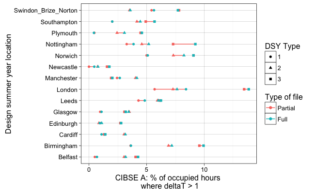

```r
for (i in 1:no.files){
  results.all = readRDS(file = paste(files.loc,results.f.names[i], sep=''))
  # for each result calculate the percentage difference between the true value and the decomposed value (in %)
  full[i,] = c(results.all$Comparison[1,])
  partial[i,] = c(results.all$Comparison[2,])
}
# process the files
Place = gsub('(_DSY)([123])(.RDS)', '', rownames(full))
WeatherFile = rownames(full)
`DSY Type` = gsub("^.*DSY","", WeatherFile)
`DSY Type` = gsub(".RDS","", `DSY Type`)
partial.df = cbind(as.data.frame(partial), Place, WeatherFile, 'Partial', `DSY Type`)
full.df = cbind(as.data.frame(full), Place, WeatherFile, 'Full', `DSY Type`)
colnames(partial.df)[6] = colnames(full.df)[6] = 'Type of file'
all.results = rbind(partial.df, full.df)
all.results$`CIBSE A` = all.results$`CIBSE A`*100 # make CIBSE A a percentage rather than a ratio
ggplot(data = all.results, aes(x = `CIBSE A`, y = Place,  color=`Type of file`, shape=`DSY Type`)) +
  geom_line(data=all.results, aes(x=`CIBSE A`, y = Place, group=WeatherFile)) +
  geom_point() +
  labs(x = "CIBSE A: % of occupied hours \n where deltaT > 1") +
  labs(y = "Design summer year location") +
  theme_linedraw()
```

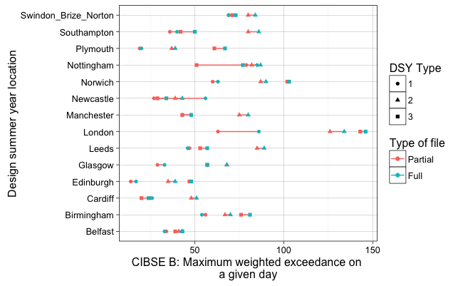

```r
ggplot(data = all.results, aes(x = `CIBSE B`, y = Place,  color=`Type of file`, shape=`DSY Type`)) +
  geom_line(data=all.results, aes(x=`CIBSE B`, y = Place, group=WeatherFile)) +
  geom_point() +
  labs(x = "CIBSE B: Maximum weighted exceedance on \na given day") +
  labs(y = "Design summer year location") +
  theme_linedraw()
```

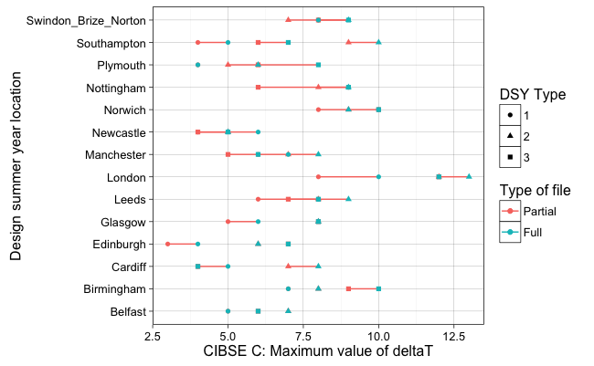

```r
ggplot(data = all.results, aes(x = `CIBSE C`, y = Place,  color=`Type of file`, shape=`DSY Type`)) +
  geom_line(data=all.results, aes(x=`CIBSE C`, y = Place, group=WeatherFile)) +
  geom_point() +
  labs(x = "CIBSE C: Maximum value of deltaT") +
  labs(y = "Design summer year location") +
  theme_linedraw()
```

For most weather / building combindations, taking out vast amounts of the weather file doesn’t make much difference to the output.

We could look at this another way. Detecting where $\Delta T$ is greater than 0 for a range of buildings could be a useful detector for overheating events.

We need to do more work to validate the results and we need to find out why some weather / building combinations are resulting in bigger differences than others.

Any ideas / comments welcome!

[^1]: Empirical mode decomposition